# Exercise 2: Extending to cause specific results

The aim of this exercise is to apply the linear integral model proposed by Horiuchi et al (2008). The example is applied to life expectancy for Venezuelan males. The aim is to quantify the effect of age-specific mortality changes on life expectancy between 1996 and 2013.

The COD object contains lifetable and cause of death data for the years 1996 and 2013. Names 1:10 are ten exhaustive and exclusive, asummed to be independent, cause-of-death groups. The exercise consists on quantifying the age and total effect of homicides on life expectancy.

First load the data

```r
library(ggplot2)
library(tidyr)
library(DemoDecomp)

#load the data
load('Decomp_Data_L4.RData')
```

Following the method, we require two vectors of rates: one for 2013 and one for 1996

```r
#we need age-cause specific mortality rates in each period
COD1        <- as.matrix(cause.age.specific.mx[cause.age.specific.mx$year==1996,1:10])

COD2        <- as.matrix(cause.age.specific.mx[cause.age.specific.mx$year==2013,1:10])
```

We already have a function for life expectancy and for the decomp algorithm

```r
 #load some functions and some info for graphs
source('Functions_5.R')
```

TRICK: What we need is then a function that gives a value of life expectancy from a vector of age-cause specific mortality

```r
e0frommxc <- function(mxcvec,sex=1){
  dim(mxcvec) <- c(19,length(mxcvec)/19)
  mx          <- rowSums(mxcvec)
  e0.frommx(mx,sex)
}
```

```r
#Now we can perfom the decomposition
Results <- horiuchi(func = e0frommxc, pars1 = c(COD1), pars2 = c(COD2), N = 100)
Results
```

```
  [1]  4.217918e-03  4.289051e-03  4.003514e-03  2.960660e-03  4.590370e-03 -8.664123e-04  2.747242e-03 -5.270914e-05  1.055335e-03  3.817584e-02
 [11]  1.180050e-02  3.009605e-02  8.301947e-02  1.171585e-01  2.181541e-01  2.024714e-01  1.880151e-01  2.100872e-01  1.786460e-01  8.808138e-04
 [21]  7.639027e-03  2.292159e-03  3.805266e-03 -1.051925e-04  1.686348e-03  1.032943e-03 -1.320688e-04  9.978341e-03  2.360649e-03  6.465372e-03
 [31] -2.594604e-03 -2.790394e-03  2.863192e-02  5.318350e-02  4.850859e-02  2.542659e-02  4.197375e-02  8.437584e-03  7.420892e-04  5.336350e-04
 [41] -1.112929e-04  3.035200e-05  1.216235e-03 -4.726468e-04 -2.025241e-03 -8.731373e-03 -4.592429e-03 -5.594204e-03  4.069768e-03 -1.446968e-02
 [51] -2.391967e-02 -3.134129e-02 -2.665327e-02 -2.326336e-02 -3.386938e-02 -2.250175e-02 -2.809696e-02  9.811376e-03 -8.564005e-04 -3.998023e-03
 [61]  2.222279e-04 -3.015918e-01 -4.632924e-01 -2.829054e-01 -1.592306e-01 -7.655504e-02 -3.980578e-02 -2.251224e-02 -2.878813e-02 -6.791860e-03
 [71] -9.007165e-03 -6.441076e-04 -2.897673e-03 -8.388509e-04  9.107804e-04 -3.382305e-03  1.952374e-03  1.273573e-02  1.720484e-02  8.619983e-03
 [81] -3.987567e-02 -6.907444e-02 -3.179930e-02 -7.137087e-03  3.143796e-04  1.461845e-02  4.719290e-02  1.201369e-02  1.751781e-02  1.870718e-02
 [91]  2.507908e-02  1.377184e-02  1.468389e-02  1.293100e-02  1.014011e-02  1.097175e-01 -2.368611e-04  2.341413e-04  0.000000e+00  0.000000e+00
[101]  0.000000e+00  0.000000e+00  0.000000e+00  0.000000e+00  0.000000e+00  0.000000e+00  0.000000e+00  0.000000e+00  0.000000e+00  0.000000e+00
[111]  0.000000e+00  0.000000e+00  0.000000e+00  0.000000e+00  7.061570e-02  3.192940e-02  1.497292e-03  1.756044e-03  3.193666e-03 -2.141591e-03
[121] -5.507002e-03 -8.272770e-03 -1.232863e-02 -5.765492e-03 -7.101358e-03 -3.115104e-03  9.171576e-04  1.502629e-03  2.379491e-02  1.373935e-02
[131]  2.739506e-02  3.646746e-02  6.257815e-03  2.606946e-01  8.350991e-02  3.926887e-03  1.445880e-03 -4.027459e-03 -1.070299e-03  7.938873e-03
[141] -8.382554e-04 -3.955282e-03 -3.408807e-03  2.577603e-02 -2.274931e-03  4.791853e-03  2.338609e-02  2.902720e-02  3.109509e-02  3.498299e-02
[151]  4.601621e-02  3.643413e-02  7.481064e-03  3.381548e-03  1.021100e-03  7.823513e-04  4.548699e-03 -7.376572e-04  2.949977e-03 -2.521133e-03
[161]  7.791995e-03  5.356852e-03  4.997657e-03  8.231921e-04 -1.951150e-03  1.001519e-02  1.718526e-02  1.323669e-02  1.572372e-02  2.508029e-02
[171]  1.179256e-02  8.246478e-02  9.552859e-02  2.929992e-02  1.666635e-02  2.365894e-02  2.436131e-02  2.754503e-02  1.352497e-02  1.739271e-02
[181]  1.850573e-02 -2.347659e-02  1.448277e-02  1.970459e-02  2.209354e-02  3.759756e-02  5.497950e-02  4.509702e-02  6.553130e-02  7.581057e-02
```

Go back to a matrix

```r
#Go back to a matrix
dim(Results) <- dim(COD1)
Results
```

```
               [,1]          [,2]          [,3]          [,4]          [,5]          [,6]          [,7]          [,8]          [,9]       [,10]
 [1,]  4.217918e-03  0.0008808138  0.0007420892  0.0098113755  0.0019523739  0.1097174910  0.0706157016  0.2606945853  0.0074810644  0.08246478
 [2,]  4.289051e-03  0.0076390274  0.0005336350 -0.0008564005  0.0127357261 -0.0002368611  0.0319294047  0.0835099105  0.0033815483  0.09552859
 [3,]  4.003514e-03  0.0022921591 -0.0001112929 -0.0039980229  0.0172048394  0.0002341413  0.0014972916  0.0039268869  0.0010211004  0.02929992
 [4,]  2.960660e-03  0.0038052662  0.0000303520  0.0002222279  0.0086199834  0.0000000000  0.0017560441  0.0014458802  0.0007823513  0.01666635
 [5,]  4.590370e-03 -0.0001051925  0.0012162349 -0.3015918057 -0.0398756696  0.0000000000  0.0031936664 -0.0040274589  0.0045486987  0.02365894
 [6,] -8.664123e-04  0.0016863482 -0.0004726468 -0.4632923831 -0.0690744422  0.0000000000 -0.0021415905 -0.0010702986 -0.0007376572  0.02436131
 [7,]  2.747242e-03  0.0010329430 -0.0020252406 -0.2829054183 -0.0317993009  0.0000000000 -0.0055070018  0.0079388729  0.0029499774  0.02754503
 [8,] -5.270914e-05 -0.0001320688 -0.0087313732 -0.1592305687 -0.0071370867  0.0000000000 -0.0082727703 -0.0008382554 -0.0025211334  0.01352497
 [9,]  1.055335e-03  0.0099783410 -0.0045924290 -0.0765550446  0.0003143796  0.0000000000 -0.0123286338 -0.0039552816  0.0077919949  0.01739271
[10,]  3.817584e-02  0.0023606488 -0.0055942042 -0.0398057830  0.0146184530  0.0000000000 -0.0057654920 -0.0034088073  0.0053568519  0.01850573
[11,]  1.180050e-02  0.0064653722  0.0040697681 -0.0225122431  0.0471929044  0.0000000000 -0.0071013576  0.0257760341  0.0049976571 -0.02347659
[12,]  3.009605e-02 -0.0025946044 -0.0144696754 -0.0287881274  0.0120136868  0.0000000000 -0.0031151045 -0.0022749310  0.0008231921  0.01448277
[13,]  8.301947e-02 -0.0027903944 -0.0239196694 -0.0067918603  0.0175178138  0.0000000000  0.0009171576  0.0047918528 -0.0019511495  0.01970459
[14,]  1.171585e-01  0.0286319222 -0.0313412899 -0.0090071645  0.0187071780  0.0000000000  0.0015026290  0.0233860872  0.0100151860  0.02209354
[15,]  2.181541e-01  0.0531834960 -0.0266532688 -0.0006441076  0.0250790751  0.0000000000  0.0237949113  0.0290272027  0.0171852627  0.03759756
[16,]  2.024714e-01  0.0485085902 -0.0232633587 -0.0028976734  0.0137718416  0.0000000000  0.0137393484  0.0310950936  0.0132366860  0.05497950
[17,]  1.880151e-01  0.0254265942 -0.0338693759 -0.0008388509  0.0146838854  0.0000000000  0.0273950602  0.0349829922  0.0157237186  0.04509702
[18,]  2.100872e-01  0.0419737541 -0.0225017533  0.0009107804  0.0129309971  0.0000000000  0.0364674639  0.0460162053  0.0250802873  0.06553130
[19,]  1.786460e-01  0.0084375844 -0.0280969591 -0.0033823053  0.0101401087  0.0000000000  0.0062578153  0.0364341295  0.0117925631  0.07581057
```

```r
#original
original <- e0frommxc(COD2) - e0frommxc(COD1)
```

with the ones obtained with the decomposition

```r
#with decomp
with.decomp <- sum(Results)
```

Just do the difference and you will get the error term

```r
original
```

```
[1] 1.651372
```

```r
with.decomp
```

```
[1] 1.65137
```

```r
#error
with.decomp - original
```

```
[1] -2.389005e-06
```

Do some data handling to have a nice dataset

```r
Results            <- data.frame(Results)
colnames(Results)  <- cause_names
Results$Age        <- c(0,1,seq(5,85,5))
rownames(Results)  <- age_names
Results            <- gather(data = Results,key = Cause,value = Contribution,-Age)
```

Finally, graph and interpret the results.

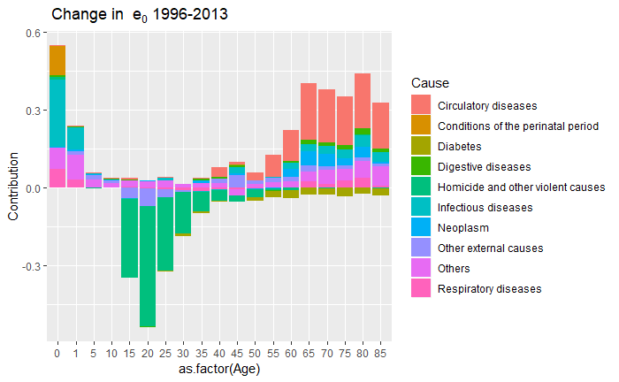

```r
#now graph results
ggplot(data=Results, aes(x=as.factor(Age), y=Contribution, fill=Cause))+
  ggtitle(bquote(~'Change in '~ e[0] ~'1996-2013' ))+
  geom_bar(stat = "identity", position = "stack")
```

# Now for lifespan variation

```r
#Now we can perfom the decomposition
Results.sd <- horiuchi(func = sdfrommxc, pars1 = c(COD1), pars2 = c(COD2), N = 100)
Results.sd
```

```
  [1] -6.393545e-03 -6.233726e-03 -5.316449e-03 -3.549595e-03 -4.904397e-03  8.121916e-04 -2.215982e-03  3.560643e-05 -5.736123e-04 -1.565710e-02
 [11] -3.241384e-03 -4.108629e-03  3.990794e-04  1.750762e-02  6.488597e-02  9.095902e-02  1.136901e-01  1.605717e-01  1.679844e-01 -1.335143e-03
 [21] -1.110260e-02 -3.043863e-03 -4.562212e-03  1.123887e-04 -1.580815e-03 -8.331929e-04  8.921599e-05 -5.423584e-03 -9.681757e-04 -1.775920e-03
 [31]  3.542082e-04 -1.341359e-05  4.278621e-03  1.581846e-02  2.179218e-02  1.537511e-02  3.208094e-02  7.934027e-03 -1.124863e-03 -7.755875e-04
 [41]  1.477910e-04 -3.638964e-05 -1.299437e-03  4.430682e-04  1.633600e-03  5.898275e-03  2.496149e-03  2.294358e-03 -1.117891e-03  1.975360e-03
 [51] -1.149832e-04 -4.683496e-03 -7.927529e-03 -1.045092e-02 -2.048034e-02 -1.719830e-02 -2.642012e-02 -1.487214e-02  1.244696e-03  5.309158e-03
 [61] -2.664336e-04  3.222237e-01  4.342992e-01  2.281973e-01  1.075645e-01  4.161039e-02  1.632559e-02  6.183703e-03  3.930075e-03 -3.264887e-05
 [71] -1.345989e-03 -1.915781e-04 -1.301761e-03 -5.072414e-04  6.961181e-04 -3.180448e-03 -2.959420e-03 -1.851016e-02 -2.284709e-02 -1.033467e-02
 [81]  4.260356e-02  6.475172e-02  2.564996e-02  4.821292e-03 -1.708765e-04 -5.995483e-03 -1.296303e-02 -1.640075e-03  8.420915e-05  2.795513e-03
 [91]  7.459314e-03  6.186913e-03  8.879140e-03  9.883284e-03  9.534944e-03 -1.663104e-01  3.442550e-04 -3.109270e-04  0.000000e+00  0.000000e+00
[101]  0.000000e+00  0.000000e+00  0.000000e+00  0.000000e+00  0.000000e+00  0.000000e+00  0.000000e+00  0.000000e+00  0.000000e+00  0.000000e+00
[111]  0.000000e+00  0.000000e+00  0.000000e+00  0.000000e+00 -1.070397e-01 -4.640634e-02 -1.988322e-03 -2.105357e-03 -3.412145e-03  2.007568e-03
[121]  4.442060e-03  5.588477e-03  6.701051e-03  2.364608e-03  1.950614e-03  4.252654e-04  4.408830e-06  2.245458e-04  7.077363e-03  6.172316e-03
[131]  1.656541e-02  2.787243e-02  5.884347e-03 -3.951624e-01 -1.213737e-01 -5.214693e-03 -1.733495e-03  4.302977e-03  1.003319e-03 -6.403656e-03
[141]  5.662638e-04  2.149836e-03  1.398058e-03 -7.080207e-03  3.105673e-04  2.303472e-05  3.494707e-03  8.633613e-03  1.396927e-02  2.115373e-02
[151]  3.517062e-02  3.425973e-02 -1.133984e-02 -4.914758e-03 -1.355966e-03 -9.379771e-04 -4.859875e-03  6.914941e-04 -2.379512e-03  1.703093e-03
[161] -4.235227e-03 -2.197012e-03 -1.372765e-03 -1.123799e-04 -9.379289e-06  1.496623e-03  5.111443e-03  5.946498e-03  9.507913e-03  1.916910e-02
[171]  1.108878e-02 -1.250006e-01 -1.388417e-01 -3.890870e-02 -1.998163e-02 -2.527745e-02 -2.283676e-02 -2.221838e-02 -9.136474e-03 -9.453557e-03
[181] -7.589775e-03  6.448592e-03 -1.977148e-03  9.472113e-05  3.301556e-03  1.118271e-02  2.469919e-02  2.726954e-02  5.008619e-02  7.128617e-02
```

Go back to a matrix

```r
#Go back to a matrix
dim(Results.sd) <- dim(COD1)
Results.sd
```

```
               [,1]          [,2]          [,3]          [,4]          [,5]         [,6]          [,7]          [,8]          [,9]         [,10]
 [1,] -6.393545e-03 -1.335143e-03 -1.124863e-03 -1.487214e-02 -2.959420e-03 -0.166310429 -1.070397e-01 -3.951624e-01 -1.133984e-02 -1.250006e-01
 [2,] -6.233726e-03 -1.110260e-02 -7.755875e-04  1.244696e-03 -1.851016e-02  0.000344255 -4.640634e-02 -1.213737e-01 -4.914758e-03 -1.388417e-01
 [3,] -5.316449e-03 -3.043863e-03  1.477910e-04  5.309158e-03 -2.284709e-02 -0.000310927 -1.988322e-03 -5.214693e-03 -1.355966e-03 -3.890870e-02
 [4,] -3.549595e-03 -4.562212e-03 -3.638964e-05 -2.664336e-04 -1.033467e-02  0.000000000 -2.105357e-03 -1.733495e-03 -9.379771e-04 -1.998163e-02
 [5,] -4.904397e-03  1.123887e-04 -1.299437e-03  3.222237e-01  4.260356e-02  0.000000000 -3.412145e-03  4.302977e-03 -4.859875e-03 -2.527745e-02
 [6,]  8.121916e-04 -1.580815e-03  4.430682e-04  4.342992e-01  6.475172e-02  0.000000000  2.007568e-03  1.003319e-03  6.914941e-04 -2.283676e-02
 [7,] -2.215982e-03 -8.331929e-04  1.633600e-03  2.281973e-01  2.564996e-02  0.000000000  4.442060e-03 -6.403656e-03 -2.379512e-03 -2.221838e-02
 [8,]  3.560643e-05  8.921599e-05  5.898275e-03  1.075645e-01  4.821292e-03  0.000000000  5.588477e-03  5.662638e-04  1.703093e-03 -9.136474e-03
 [9,] -5.736123e-04 -5.423584e-03  2.496149e-03  4.161039e-02 -1.708765e-04  0.000000000  6.701051e-03  2.149836e-03 -4.235227e-03 -9.453557e-03
[10,] -1.565710e-02 -9.681757e-04  2.294358e-03  1.632559e-02 -5.995483e-03  0.000000000  2.364608e-03  1.398058e-03 -2.197012e-03 -7.589775e-03
[11,] -3.241384e-03 -1.775920e-03 -1.117891e-03  6.183703e-03 -1.296303e-02  0.000000000  1.950614e-03 -7.080207e-03 -1.372765e-03  6.448592e-03
[12,] -4.108629e-03  3.542082e-04  1.975360e-03  3.930075e-03 -1.640075e-03  0.000000000  4.252654e-04  3.105673e-04 -1.123799e-04 -1.977148e-03
[13,]  3.990794e-04 -1.341359e-05 -1.149832e-04 -3.264887e-05  8.420915e-05  0.000000000  4.408830e-06  2.303472e-05 -9.379289e-06  9.472113e-05
[14,]  1.750762e-02  4.278621e-03 -4.683496e-03 -1.345989e-03  2.795513e-03  0.000000000  2.245458e-04  3.494707e-03  1.496623e-03  3.301556e-03
[15,]  6.488597e-02  1.581846e-02 -7.927529e-03 -1.915781e-04  7.459314e-03  0.000000000  7.077363e-03  8.633613e-03  5.111443e-03  1.118271e-02
[16,]  9.095902e-02  2.179218e-02 -1.045092e-02 -1.301761e-03  6.186913e-03  0.000000000  6.172316e-03  1.396927e-02  5.946498e-03  2.469919e-02
[17,]  1.136901e-01  1.537511e-02 -2.048034e-02 -5.072414e-04  8.879140e-03  0.000000000  1.656541e-02  2.115373e-02  9.507913e-03  2.726954e-02
[18,]  1.605717e-01  3.208094e-02 -1.719830e-02  6.961181e-04  9.883284e-03  0.000000000  2.787243e-02  3.517062e-02  1.916910e-02  5.008619e-02
[19,]  1.679844e-01  7.934027e-03 -2.642012e-02 -3.180448e-03  9.534944e-03  0.000000000  5.884347e-03  3.425973e-02  1.108878e-02  7.128617e-02
```

```r
 sdfrommxc(COD2) - sdfrommxc(COD1)
```

```
[1] 0.9518884
```

with the ones obtained with the decomposition

```r
with.decomp.sd
```

```
[1] 0.9518872
```

Just do the difference and you will get the error term

```r
original.sd
```

```
[1] 0.9518884
```

```r
with.decomp.sd
```

```
[1] 0.9518872
```

```r
#error
with.decomp - original.sd
```

[output not shown]

Do some data handling to have a nice dataset

```r
Results.sd            <- data.frame(Results.sd)
colnames(Results.sd)  <- cause_names
Results.sd$Age        <- c(0,1,seq(5,85,5))
rownames(Results.sd)  <- age_names
Results.sd            <- gather(data = Results.sd,key = Cause,value = Contribution,-Age)
```

Finally, graph and interpret the results.

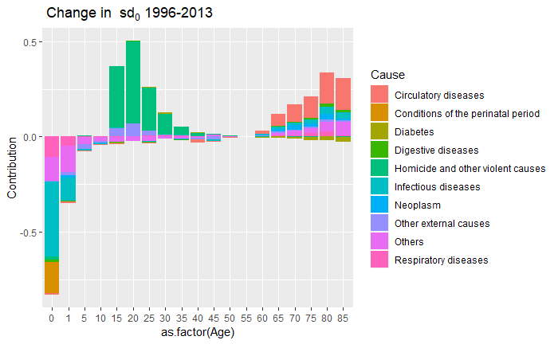

```r
#now graph results
ggplot(data=Results.sd, aes(x=as.factor(Age), y=Contribution, fill=Cause))+
  ggtitle(bquote(~'Change in '~ sd[0] ~'1996-2013' ))+
  geom_bar(stat = "identity", position = "stack")
```